# Risk Factor Analysis

## Outcome Variable

**Outcome Variable:** ever_wasted

## Predictor Variables

**Intervention Variable:** birthlen

**Adjustment Set:**

- arm
- sex
- W_mage
- meducyrs
- feducyrs
- hhwealth_quart
- vagbrth
- W_nrooms
- brthmon
- W_parity
- impfloor
- impsan
- safeh20
- delta_W_mage
- delta_meducyrs
- delta_feducyrs
- delta_hhwealth_quart
- delta_vagbrth
- delta_W_nrooms
- delta_brthmon
- delta_W_parity
- delta_impfloor
- delta_impsan
- delta_safeh20

## Stratifying Variables

The analysis was stratified on these variable(s):

- agecat
- studyid
- country

## Data Summary

| agecat | studyid | country | birthlen | ever_wasted | n_cell | n |
| --- | --- | --- | --- | --- | --- | --- |
| 0-24 months (no birth wast) | ki0047075b-MAL-ED | BANGLADESH | >=50 cm | 0 | 23 | 256 |
| 0-24 months (no birth wast) | ki0047075b-MAL-ED | BANGLADESH | >=50 cm | 1 | 6 | 256 |
| 0-24 months (no birth wast) | ki0047075b-MAL-ED | BANGLADESH | <48 cm | 0 | 107 | 256 |
| 0-24 months (no birth wast) | ki0047075b-MAL-ED | BANGLADESH | <48 cm | 1 | 35 | 256 |
| 0-24 months (no birth wast) | ki0047075b-MAL-ED | BANGLADESH | [48-50) cm | 0 | 70 | 256 |
| 0-24 months (no birth wast) | ki0047075b-MAL-ED | BANGLADESH | [48-50) cm | 1 | 15 | 256 |
| 0-24 months (no birth wast) | ki0047075b-MAL-ED | BRAZIL | >=50 cm | 0 | 32 | 191 |
| 0-24 months (no birth wast) | ki0047075b-MAL-ED | BRAZIL | >=50 cm | 1 | 2 | 191 |
| 0-24 months (no birth wast) | ki0047075b-MAL-ED | BRAZIL | <48 cm | 0 | 74 | 191 |
| 0-24 months (no birth wast) | ki0047075b-MAL-ED | BRAZIL | <48 cm | 1 | 6 | 191 |
| 0-24 months (no birth wast) | ki0047075b-MAL-ED | BRAZIL | [48-50) cm | 0 | 73 | 191 |
| 0-24 months (no birth wast) | ki0047075b-MAL-ED | BRAZIL | [48-50) cm | 1 | 4 | 191 |
| 0-24 months (no birth wast) | ki0047075b-MAL-ED | INDIA | >=50 cm | 0 | 17 | 203 |
| 0-24 months (no birth wast) | ki0047075b-MAL-ED | INDIA | >=50 cm | 1 | 8 | 203 |
| 0-24 months (no birth wast) | ki0047075b-MAL-ED | INDIA | <48 cm | 0 | 68 | 203 |
| 0-24 months (no birth wast) | ki0047075b-MAL-ED | INDIA | <48 cm | 1 | 38 | 203 |
| 0-24 months (no birth wast) | ki0047075b-MAL-ED | INDIA | [48-50) cm | 0 | 48 | 203 |
| 0-24 months (no birth wast) | ki0047075b-MAL-ED | INDIA | [48-50) cm | 1 | 24 | 203 |
| 0-24 months (no birth wast) | ki0047075b-MAL-ED | NEPAL | >=50 cm | 0 | 33 | 173 |
| 0-24 months (no birth wast) | ki0047075b-MAL-ED | NEPAL | >=50 cm | 1 | 5 | 173 |
| 0-24 months (no birth wast) | ki0047075b-MAL-ED | NEPAL | <48 cm | 0 | 48 | 173 |
| 0-24 months (no birth wast) | ki0047075b-MAL-ED | NEPAL | <48 cm | 1 | 21 | 173 |
| 0-24 months (no birth wast) | ki0047075b-MAL-ED | NEPAL | [48-50) cm | 0 | 58 | 173 |
| 0-24 months (no birth wast) | ki0047075b-MAL-ED | NEPAL | [48-50) cm | 1 | 8 | 173 |
| 0-24 months (no birth wast) | ki0047075b-MAL-ED | PERU | >=50 cm | 0 | 32 | 288 |
| 0-24 months (no birth wast) | ki0047075b-MAL-ED | PERU | >=50 cm | 1 | 2 | 288 |
| 0-24 months (no birth wast) | ki0047075b-MAL-ED | PERU | <48 cm | 0 | 129 | 288 |
| 0-24 months (no birth wast) | ki0047075b-MAL-ED | PERU | <48 cm | 1 | 13 | 288 |
| 0-24 months (no birth wast) | ki0047075b-MAL-ED | PERU | [48-50) cm | 0 | 107 | 288 |
| 0-24 months (no birth wast) | ki0047075b-MAL-ED | PERU | [48-50) cm | 1 | 5 | 288 |

[output cut: 474 more lines]

The following strata were considered:

- agecat: 0-24 months (no birth wast), studyid: ki0047075b-MAL-ED, country: BANGLADESH
- agecat: 0-24 months (no birth wast), studyid: ki0047075b-MAL-ED, country: BRAZIL
- agecat: 0-24 months (no birth wast), studyid: ki0047075b-MAL-ED, country: INDIA
- agecat: 0-24 months (no birth wast), studyid: ki0047075b-MAL-ED, country: NEPAL
- agecat: 0-24 months (no birth wast), studyid: ki0047075b-MAL-ED, country: PERU
- agecat: 0-24 months (no birth wast), studyid: ki0047075b-MAL-ED, country: SOUTH AFRICA
- agecat: 0-24 months (no birth wast), studyid: ki0047075b-MAL-ED, country: TANZANIA, UNITED REPUBLIC OF
- agecat: 0-24 months (no birth wast), studyid: ki1000108-CMC-V-BCS-2002, country: INDIA
- agecat: 0-24 months (no birth wast), studyid: ki1000108-IRC, country: INDIA
- agecat: 0-24 months (no birth wast), studyid: ki1000109-EE, country: PAKISTAN
- agecat: 0-24 months (no birth wast), studyid: ki1000109-ResPak, country: PAKISTAN
- agecat: 0-24 months (no birth wast), studyid: ki1000304b-SAS-CompFeed, country: INDIA
- agecat: 0-24 months (no birth wast), studyid: ki1017093-NIH-Birth, country: BANGLADESH
- agecat: 0-24 months (no birth wast), studyid: ki1017093b-PROVIDE, country: BANGLADESH
- agecat: 0-24 months (no birth wast), studyid: ki1017093c-NIH-Crypto, country: BANGLADESH
- agecat: 0-24 months (no birth wast), studyid: ki1101329-Keneba, country: GAMBIA
- agecat: 0-24 months (no birth wast), studyid: ki1114097-CMIN, country: BANGLADESH
- agecat: 0-24 months (no birth wast), studyid: ki1114097-CMIN, country: BRAZIL
- agecat: 0-24 months (no birth wast), studyid: ki1114097-CMIN, country: GUINEA-BISSAU
- agecat: 0-24 months (no birth wast), studyid: ki1114097-CMIN, country: PERU
- agecat: 0-24 months (no birth wast), studyid: ki1114097-CONTENT, country: PERU
- agecat: 0-24 months (no birth wast), studyid: ki1119695-PROBIT, country: BELARUS
- agecat: 0-24 months (no birth wast), studyid: ki1126311-ZVITAMBO, country: ZIMBABWE
- agecat: 0-24 months (no birth wast), studyid: ki1135781-COHORTS, country: GUATEMALA
- agecat: 0-24 months (no birth wast), studyid: ki1135781-COHORTS, country: INDIA
- agecat: 0-24 months (no birth wast), studyid: ki1135781-COHORTS, country: PHILIPPINES
- agecat: 0-24 months (no birth wast), studyid: kiGH5241-JiVitA-3, country: BANGLADESH
- agecat: 0-24 months (no birth wast), studyid: kiGH5241-JiVitA-4, country: BANGLADESH
- agecat: 0-6 months (no birth wast), studyid: ki0047075b-MAL-ED, country: BANGLADESH
- agecat: 0-6 months (no birth wast), studyid: ki0047075b-MAL-ED, country: BRAZIL
- agecat: 0-6 months (no birth wast), studyid: ki0047075b-MAL-ED, country: INDIA
- agecat: 0-6 months (no birth wast), studyid: ki0047075b-MAL-ED, country: NEPAL
- agecat: 0-6 months (no birth wast), studyid: ki0047075b-MAL-ED, country: PERU
- agecat: 0-6 months (no birth wast), studyid: ki0047075b-MAL-ED, country: SOUTH AFRICA
- agecat: 0-6 months (no birth wast), studyid: ki0047075b-MAL-ED, country: TANZANIA, UNITED REPUBLIC OF
- agecat: 0-6 months (no birth wast), studyid: ki1000108-CMC-V-BCS-2002, country: INDIA
- agecat: 0-6 months (no birth wast), studyid: ki1000108-IRC, country: INDIA
- agecat: 0-6 months (no birth wast), studyid: ki1000109-EE, country: PAKISTAN
- agecat: 0-6 months (no birth wast), studyid: ki1000109-ResPak, country: PAKISTAN
- agecat: 0-6 months (no birth wast), studyid: ki1000304b-SAS-CompFeed, country: INDIA
- agecat: 0-6 months (no birth wast), studyid: ki1017093-NIH-Birth, country: BANGLADESH
- agecat: 0-6 months (no birth wast), studyid: ki1017093b-PROVIDE, country: BANGLADESH
- agecat: 0-6 months (no birth wast), studyid: ki1017093c-NIH-Crypto, country: BANGLADESH
- agecat: 0-6 months (no birth wast), studyid: ki1101329-Keneba, country: GAMBIA
- agecat: 0-6 months (no birth wast), studyid: ki1114097-CMIN, country: BANGLADESH
- agecat: 0-6 months (no birth wast), studyid: ki1114097-CMIN, country: BRAZIL
- agecat: 0-6 months (no birth wast), studyid: ki1114097-CMIN, country: GUINEA-BISSAU
- agecat: 0-6 months (no birth wast), studyid: ki1114097-CMIN, country: PERU
- agecat: 0-6 months (no birth wast), studyid: ki1114097-CONTENT, country: PERU
- agecat: 0-6 months (no birth wast), studyid: ki1119695-PROBIT, country: BELARUS
- agecat: 0-6 months (no birth wast), studyid: ki1126311-ZVITAMBO, country: ZIMBABWE
- agecat: 0-6 months (no birth wast), studyid: ki1135781-COHORTS, country: GUATEMALA
- agecat: 0-6 months (no birth wast), studyid: ki1135781-COHORTS, country: INDIA
- agecat: 0-6 months (no birth wast), studyid: ki1135781-COHORTS, country: PHILIPPINES
- agecat: 0-6 months (no birth wast), studyid: kiGH5241-JiVitA-3, country: BANGLADESH
- agecat: 0-6 months (no birth wast), studyid: kiGH5241-JiVitA-4, country: BANGLADESH
- agecat: 6-24 months, studyid: ki0047075b-MAL-ED, country: BANGLADESH
- agecat: 6-24 months, studyid: ki0047075b-MAL-ED, country: BRAZIL
- agecat: 6-24 months, studyid: ki0047075b-MAL-ED, country: INDIA
- agecat: 6-24 months, studyid: ki0047075b-MAL-ED, country: NEPAL
- agecat: 6-24 months, studyid: ki0047075b-MAL-ED, country: PERU
- agecat: 6-24 months, studyid: ki0047075b-MAL-ED, country: SOUTH AFRICA
- agecat: 6-24 months, studyid: ki0047075b-MAL-ED, country: TANZANIA, UNITED REPUBLIC OF
- agecat: 6-24 months, studyid: ki1000108-CMC-V-BCS-2002, country: INDIA
- agecat: 6-24 months, studyid: ki1000108-IRC, country: INDIA
- agecat: 6-24 months, studyid: ki1000109-EE, country: PAKISTAN
- agecat: 6-24 months, studyid: ki1000109-ResPak, country: PAKISTAN
- agecat: 6-24 months, studyid: ki1000304b-SAS-CompFeed, country: INDIA
- agecat: 6-24 months, studyid: ki1017093-NIH-Birth, country: BANGLADESH
- agecat: 6-24 months, studyid: ki1017093b-PROVIDE, country: BANGLADESH
- agecat: 6-24 months, studyid: ki1017093c-NIH-Crypto, country: BANGLADESH
- agecat: 6-24 months, studyid: ki1101329-Keneba, country: GAMBIA
- agecat: 6-24 months, studyid: ki1114097-CMIN, country: BANGLADESH
- agecat: 6-24 months, studyid: ki1114097-CMIN, country: BRAZIL
- agecat: 6-24 months, studyid: ki1114097-CMIN, country: GUINEA-BISSAU
- agecat: 6-24 months, studyid: ki1114097-CMIN, country: PERU
- agecat: 6-24 months, studyid: ki1114097-CONTENT, country: PERU
- agecat: 6-24 months, studyid: ki1119695-PROBIT, country: BELARUS
- agecat: 6-24 months, studyid: ki1126311-ZVITAMBO, country: ZIMBABWE
- agecat: 6-24 months, studyid: ki1135781-COHORTS, country: GUATEMALA
- agecat: 6-24 months, studyid: ki1135781-COHORTS, country: INDIA
- agecat: 6-24 months, studyid: ki1135781-COHORTS, country: PHILIPPINES
- agecat: 6-24 months, studyid: kiGH5241-JiVitA-3, country: BANGLADESH
- agecat: 6-24 months, studyid: kiGH5241-JiVitA-4, country: BANGLADESH

### Dropped Strata

Some strata were dropped due to rare outcomes:

- agecat: 0-24 months (no birth wast), studyid: ki0047075b-MAL-ED, country: BRAZIL
- agecat: 0-24 months (no birth wast), studyid: ki0047075b-MAL-ED, country: PERU
- agecat: 0-24 months (no birth wast), studyid: ki0047075b-MAL-ED, country: TANZANIA, UNITED REPUBLIC OF
- agecat: 0-24 months (no birth wast), studyid: ki1000109-ResPak, country: PAKISTAN
- agecat: 0-24 months (no birth wast), studyid: ki1114097-CMIN, country: BANGLADESH
- agecat: 0-24 months (no birth wast), studyid: ki1114097-CMIN, country: BRAZIL
- agecat: 0-24 months (no birth wast), studyid: ki1114097-CMIN, country: GUINEA-BISSAU
- agecat: 0-24 months (no birth wast), studyid: ki1114097-CMIN, country: PERU
- agecat: 0-24 months (no birth wast), studyid: ki1114097-CONTENT, country: PERU
- agecat: 0-6 months (no birth wast), studyid: ki0047075b-MAL-ED, country: BANGLADESH
- agecat: 0-6 months (no birth wast), studyid: ki0047075b-MAL-ED, country: BRAZIL
- agecat: 0-6 months (no birth wast), studyid: ki0047075b-MAL-ED, country: NEPAL
- agecat: 0-6 months (no birth wast), studyid: ki0047075b-MAL-ED, country: PERU
- agecat: 0-6 months (no birth wast), studyid: ki0047075b-MAL-ED, country: SOUTH AFRICA
- agecat: 0-6 months (no birth wast), studyid: ki0047075b-MAL-ED, country: TANZANIA, UNITED REPUBLIC OF
- agecat: 0-6 months (no birth wast), studyid: ki1000109-ResPak, country: PAKISTAN
- agecat: 0-6 months (no birth wast), studyid: ki1017093-NIH-Birth, country: BANGLADESH
- agecat: 0-6 months (no birth wast), studyid: ki1114097-CMIN, country: BANGLADESH
- agecat: 0-6 months (no birth wast), studyid: ki1114097-CMIN, country: BRAZIL
- agecat: 0-6 months (no birth wast), studyid: ki1114097-CMIN, country: GUINEA-BISSAU
- agecat: 0-6 months (no birth wast), studyid: ki1114097-CMIN, country: PERU
- agecat: 0-6 months (no birth wast), studyid: ki1114097-CONTENT, country: PERU
- agecat: 6-24 months, studyid: ki0047075b-MAL-ED, country: BANGLADESH
- agecat: 6-24 months, studyid: ki0047075b-MAL-ED, country: BRAZIL
- agecat: 6-24 months, studyid: ki0047075b-MAL-ED, country: INDIA
- agecat: 6-24 months, studyid: ki0047075b-MAL-ED, country: NEPAL
- agecat: 6-24 months, studyid: ki0047075b-MAL-ED, country: PERU
- agecat: 6-24 months, studyid: ki0047075b-MAL-ED, country: SOUTH AFRICA
- agecat: 6-24 months, studyid: ki0047075b-MAL-ED, country: TANZANIA, UNITED REPUBLIC OF
- agecat: 6-24 months, studyid: ki1000108-CMC-V-BCS-2002, country: INDIA
- agecat: 6-24 months, studyid: ki1000109-ResPak, country: PAKISTAN
- agecat: 6-24 months, studyid: ki1114097-CMIN, country: BANGLADESH
- agecat: 6-24 months, studyid: ki1114097-CMIN, country: BRAZIL
- agecat: 6-24 months, studyid: ki1114097-CMIN, country: GUINEA-BISSAU
- agecat: 6-24 months, studyid: ki1114097-CMIN, country: PERU
- agecat: 6-24 months, studyid: ki1114097-CONTENT, country: PERU
- agecat: 6-24 months, studyid: ki1119695-PROBIT, country: BELARUS

## Methods Detail

We’re interested in the causal parameters $E[Y_a]$ for all values of $a \in \mathcal{A}$. These parameters represent the mean outcome if, possibly contrary to fact, we intervened to set all units to have $A=a$. Under the randomization and positivity assumptions, these are identified by the statistical parameters $\psi_a=E_W[E_{Y|A,W}(Y|A=a,W)]$. In addition, we’re interested in the mean of $Y$, $E[Y]$ under no intervention (the observed mean). We will estimate these parameters by using SuperLearner to fit the relevant likelihood factors – $E_{Y|A,W}(Y|A=a,W)$ and $p(A=a|W)$, and then updating our likelihood fit using a joint TMLE.

For unadjusted analyses ($W=\{\}$), initial likelihoods were estimated using Lrnr_glm to estimate the simple $E(Y|A)$ and Lrnr_mean to estimate $p(A)$. For adjusted analyses, a small library containing Lrnr_glmnet, Lrnr_xgboost, and Lrnr_mean was used.

Having estimated these parameters, we will then use the delta method to estimate relative risks and attributable risks relative to a prespecified baseline level of $A$.

# Results Detail

## Results Plots

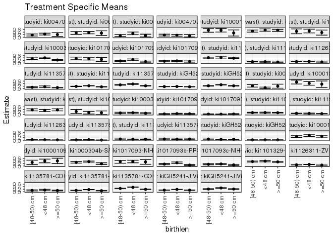

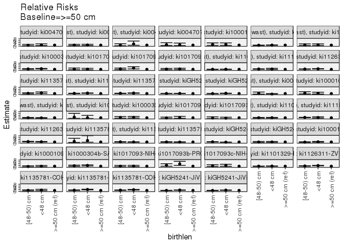

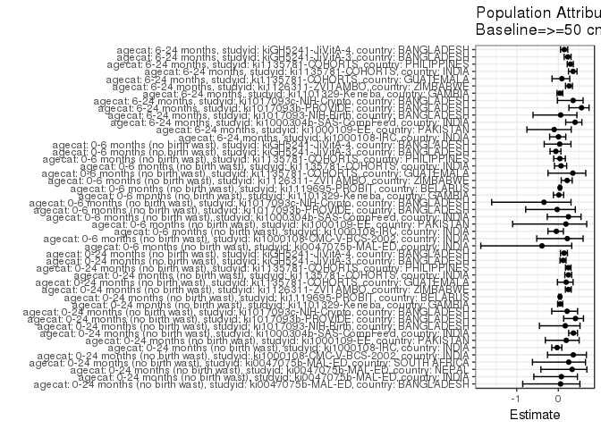

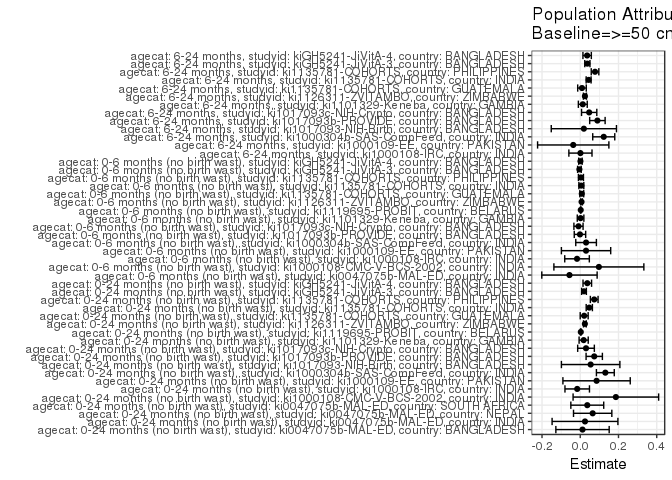

## Results Table

### Parameter: TSM

| agecat | studyid | country | intervention_level | baseline_level | estimate | ci_lower | ci_upper |
| --- | --- | --- | --- | --- | --- | --- | --- |
| 0-24 months (no birth wast) | ki0047075b-MAL-ED | BANGLADESH | >=50 cm | NA | 0.2068966 | 0.0591761 | 0.3546170 |
| 0-24 months (no birth wast) | ki0047075b-MAL-ED | BANGLADESH | <48 cm | NA | 0.2464789 | 0.1754571 | 0.3175006 |
| 0-24 months (no birth wast) | ki0047075b-MAL-ED | BANGLADESH | [48-50) cm | NA | 0.1764706 | 0.0952691 | 0.2576721 |
| 0-24 months (no birth wast) | ki0047075b-MAL-ED | INDIA | >=50 cm | NA | 0.3200000 | 0.1366927 | 0.5033073 |
| 0-24 months (no birth wast) | ki0047075b-MAL-ED | INDIA | <48 cm | NA | 0.3584906 | 0.2669723 | 0.4500089 |
| 0-24 months (no birth wast) | ki0047075b-MAL-ED | INDIA | [48-50) cm | NA | 0.3333333 | 0.2241773 | 0.4424894 |
| 0-24 months (no birth wast) | ki0047075b-MAL-ED | NEPAL | >=50 cm | NA | 0.1315789 | 0.0237902 | 0.2393677 |
| 0-24 months (no birth wast) | ki0047075b-MAL-ED | NEPAL | <48 cm | NA | 0.3043478 | 0.1954640 | 0.4132317 |
| 0-24 months (no birth wast) | ki0047075b-MAL-ED | NEPAL | [48-50) cm | NA | 0.1212121 | 0.0422443 | 0.2001799 |
| 0-24 months (no birth wast) | ki0047075b-MAL-ED | SOUTH AFRICA | >=50 cm | NA | 0.1111111 | 0.0191105 | 0.2031118 |
| 0-24 months (no birth wast) | ki0047075b-MAL-ED | SOUTH AFRICA | <48 cm | NA | 0.1454545 | 0.0794415 | 0.2114676 |
| 0-24 months (no birth wast) | ki0047075b-MAL-ED | SOUTH AFRICA | [48-50) cm | NA | 0.1666667 | 0.0942017 | 0.2391317 |
| 0-24 months (no birth wast) | ki1000108-CMC-V-BCS-2002 | INDIA | >=50 cm | NA | 0.3333333 | 0.0935960 | 0.5730706 |
| 0-24 months (no birth wast) | ki1000108-CMC-V-BCS-2002 | INDIA | <48 cm | NA | 0.5531915 | 0.4103557 | 0.6960273 |
| 0-24 months (no birth wast) | ki1000108-CMC-V-BCS-2002 | INDIA | [48-50) cm | NA | 0.5500000 | 0.3950666 | 0.7049334 |
| 0-24 months (no birth wast) | ki1000108-IRC | INDIA | >=50 cm | NA | 0.5466524 | 0.4659002 | 0.6274046 |
| 0-24 months (no birth wast) | ki1000108-IRC | INDIA | <48 cm | NA | 0.5679051 | 0.4776666 | 0.6581436 |
| 0-24 months (no birth wast) | ki1000108-IRC | INDIA | [48-50) cm | NA | 0.4844135 | 0.4021728 | 0.5666541 |
| 0-24 months (no birth wast) | ki1000109-EE | PAKISTAN | >=50 cm | NA | 0.3651585 | 0.1650586 | 0.5652585 |
| 0-24 months (no birth wast) | ki1000109-EE | PAKISTAN | <48 cm | NA | 0.4884966 | 0.3394123 | 0.6375809 |
| 0-24 months (no birth wast) | ki1000109-EE | PAKISTAN | [48-50) cm | NA | 0.4621809 | 0.2702547 | 0.6541070 |
| 0-24 months (no birth wast) | ki1000304b-SAS-CompFeed | INDIA | >=50 cm | NA | 0.2314143 | 0.1887119 | 0.2741167 |
| 0-24 months (no birth wast) | ki1000304b-SAS-CompFeed | INDIA | <48 cm | NA | 0.3996734 | 0.3422934 | 0.4570535 |
| 0-24 months (no birth wast) | ki1000304b-SAS-CompFeed | INDIA | [48-50) cm | NA | 0.3358931 | 0.2684309 | 0.4033554 |
| 0-24 months (no birth wast) | ki1017093-NIH-Birth | BANGLADESH | >=50 cm | NA | 0.2758621 | 0.1128131 | 0.4389110 |
| 0-24 months (no birth wast) | ki1017093-NIH-Birth | BANGLADESH | <48 cm | NA | 0.3238095 | 0.2340986 | 0.4135204 |
| 0-24 months (no birth wast) | ki1017093-NIH-Birth | BANGLADESH | [48-50) cm | NA | 0.3580247 | 0.2533761 | 0.4626733 |
| 0-24 months (no birth wast) | ki1017093b-PROVIDE | BANGLADESH | >=50 cm | NA | 0.1044381 | 0.0596940 | 0.1491822 |
| 0-24 months (no birth wast) | ki1017093b-PROVIDE | BANGLADESH | <48 cm | NA | 0.2616005 | 0.2075651 | 0.3156358 |
| 0-24 months (no birth wast) | ki1017093b-PROVIDE | BANGLADESH | [48-50) cm | NA | 0.1570282 | 0.1156268 | 0.1984297 |

[output cut: 111 more lines]

### Parameter: E(Y)

| agecat | studyid | country | intervention_level | baseline_level | estimate | ci_lower | ci_upper |
| --- | --- | --- | --- | --- | --- | --- | --- |
| 0-24 months (no birth wast) | ki0047075b-MAL-ED | BANGLADESH | NA | NA | 0.2187500 | 0.1680104 | 0.2694896 |
| 0-24 months (no birth wast) | ki0047075b-MAL-ED | INDIA | NA | NA | 0.3448276 | 0.2792808 | 0.4103743 |
| 0-24 months (no birth wast) | ki0047075b-MAL-ED | NEPAL | NA | NA | 0.1965318 | 0.1371457 | 0.2559179 |
| 0-24 months (no birth wast) | ki0047075b-MAL-ED | SOUTH AFRICA | NA | NA | 0.1478599 | 0.1043780 | 0.1913419 |
| 0-24 months (no birth wast) | ki1000108-CMC-V-BCS-2002 | INDIA | NA | NA | 0.5196078 | 0.4221710 | 0.6170447 |
| 0-24 months (no birth wast) | ki1000108-IRC | INDIA | NA | NA | 0.5307692 | 0.4811763 | 0.5803621 |
| 0-24 months (no birth wast) | ki1000109-EE | PAKISTAN | NA | NA | 0.4505495 | 0.3477567 | 0.5533422 |
| 0-24 months (no birth wast) | ki1000304b-SAS-CompFeed | INDIA | NA | NA | 0.3626595 | 0.3120201 | 0.4132989 |
| 0-24 months (no birth wast) | ki1017093-NIH-Birth | BANGLADESH | NA | NA | 0.3302326 | 0.2672220 | 0.3932431 |
| 0-24 months (no birth wast) | ki1017093b-PROVIDE | BANGLADESH | NA | NA | 0.1775837 | 0.1489858 | 0.2061816 |
| 0-24 months (no birth wast) | ki1017093c-NIH-Crypto | BANGLADESH | NA | NA | 0.1432361 | 0.1182149 | 0.1682572 |
| 0-24 months (no birth wast) | ki1101329-Keneba | GAMBIA | NA | NA | 0.3939198 | 0.3695556 | 0.4182840 |
| 0-24 months (no birth wast) | ki1119695-PROBIT | BELARUS | NA | NA | 0.0716952 | 0.0597165 | 0.0836739 |
| 0-24 months (no birth wast) | ki1126311-ZVITAMBO | ZIMBABWE | NA | NA | 0.0997183 | 0.0946616 | 0.1047750 |
| 0-24 months (no birth wast) | ki1135781-COHORTS | GUATEMALA | NA | NA | 0.1096224 | 0.0882390 | 0.1310059 |
| 0-24 months (no birth wast) | ki1135781-COHORTS | INDIA | NA | NA | 0.1948438 | 0.1851392 | 0.2045483 |
| 0-24 months (no birth wast) | ki1135781-COHORTS | PHILIPPINES | NA | NA | 0.3035536 | 0.2871278 | 0.3199794 |
| 0-24 months (no birth wast) | kiGH5241-JiVitA-3 | BANGLADESH | NA | NA | 0.1700683 | 0.1646983 | 0.1754383 |
| 0-24 months (no birth wast) | kiGH5241-JiVitA-4 | BANGLADESH | NA | NA | 0.2663530 | 0.2512746 | 0.2814315 |
| 0-6 months (no birth wast) | ki0047075b-MAL-ED | INDIA | NA | NA | 0.1435644 | 0.0950890 | 0.1920397 |
| 0-6 months (no birth wast) | ki1000108-CMC-V-BCS-2002 | INDIA | NA | NA | 0.4545455 | 0.3559622 | 0.5531287 |
| 0-6 months (no birth wast) | ki1000108-IRC | INDIA | NA | NA | 0.3494624 | 0.3009450 | 0.3979798 |
| 0-6 months (no birth wast) | ki1000109-EE | PAKISTAN | NA | NA | 0.1666667 | 0.0892407 | 0.2440927 |
| 0-6 months (no birth wast) | ki1000304b-SAS-CompFeed | INDIA | NA | NA | 0.1264525 | 0.0961151 | 0.1567899 |
| 0-6 months (no birth wast) | ki1017093b-PROVIDE | BANGLADESH | NA | NA | 0.0527086 | 0.0359384 | 0.0694789 |
| 0-6 months (no birth wast) | ki1017093c-NIH-Crypto | BANGLADESH | NA | NA | 0.0267023 | 0.0151493 | 0.0382553 |
| 0-6 months (no birth wast) | ki1101329-Keneba | GAMBIA | NA | NA | 0.1402238 | 0.1227569 | 0.1576907 |
| 0-6 months (no birth wast) | ki1119695-PROBIT | BELARUS | NA | NA | 0.0637570 | 0.0524446 | 0.0750694 |
| 0-6 months (no birth wast) | ki1126311-ZVITAMBO | ZIMBABWE | NA | NA | 0.0321704 | 0.0291649 | 0.0351759 |
| 0-6 months (no birth wast) | ki1135781-COHORTS | GUATEMALA | NA | NA | 0.0226986 | 0.0123257 | 0.0330715 |
| 0-6 months (no birth wast) | ki1135781-COHORTS | INDIA | NA | NA | 0.0880701 | 0.0809295 | 0.0952106 |
| 0-6 months (no birth wast) | ki1135781-COHORTS | PHILIPPINES | NA | NA | 0.0946488 | 0.0841546 | 0.1051431 |
| 0-6 months (no birth wast) | kiGH5241-JiVitA-3 | BANGLADESH | NA | NA | 0.0723218 | 0.0686288 | 0.0760148 |
| 0-6 months (no birth wast) | kiGH5241-JiVitA-4 | BANGLADESH | NA | NA | 0.0289057 | 0.0236101 | 0.0342013 |
| 6-24 months | ki1000108-IRC | INDIA | NA | NA | 0.3145780 | 0.2684931 | 0.3606629 |
| 6-24 months | ki1000109-EE | PAKISTAN | NA | NA | 0.3636364 | 0.2625541 | 0.4647186 |
| 6-24 months | ki1000304b-SAS-CompFeed | INDIA | NA | NA | 0.3059593 | 0.2629068 | 0.3490118 |
| 6-24 months | ki1017093-NIH-Birth | BANGLADESH | NA | NA | 0.3388889 | 0.2695483 | 0.4082295 |
| 6-24 months | ki1017093b-PROVIDE | BANGLADESH | NA | NA | 0.1609756 | 0.1319065 | 0.1900447 |
| 6-24 months | ki1017093c-NIH-Crypto | BANGLADESH | NA | NA | 0.1315068 | 0.1069744 | 0.1560393 |
| 6-24 months | ki1101329-Keneba | GAMBIA | NA | NA | 0.3369200 | 0.3128882 | 0.3609517 |
| 6-24 months | ki1126311-ZVITAMBO | ZIMBABWE | NA | NA | 0.0937559 | 0.0881988 | 0.0993131 |
| 6-24 months | ki1135781-COHORTS | GUATEMALA | NA | NA | 0.1059147 | 0.0835302 | 0.1282992 |
| 6-24 months | ki1135781-COHORTS | INDIA | NA | NA | 0.1238450 | 0.1156244 | 0.1320657 |
| 6-24 months | ki1135781-COHORTS | PHILIPPINES | NA | NA | 0.2665953 | 0.2502200 | 0.2829706 |
| 6-24 months | kiGH5241-JiVitA-3 | BANGLADESH | NA | NA | 0.1638967 | 0.1577233 | 0.1700702 |
| 6-24 months | kiGH5241-JiVitA-4 | BANGLADESH | NA | NA | 0.2510058 | 0.2361044 | 0.2659072 |

### Parameter: RR

| agecat | studyid | country | intervention_level | baseline_level | estimate | ci_lower | ci_upper |
| --- | --- | --- | --- | --- | --- | --- | --- |
| 0-24 months (no birth wast) | ki0047075b-MAL-ED | BANGLADESH | >=50 cm | >=50 cm | 1.0000000 | 1.0000000 | 1.0000000 |
| 0-24 months (no birth wast) | ki0047075b-MAL-ED | BANGLADESH | <48 cm | >=50 cm | 1.1913146 | 0.5516307 | 2.5727907 |
| 0-24 months (no birth wast) | ki0047075b-MAL-ED | BANGLADESH | [48-50) cm | >=50 cm | 0.8529412 | 0.3647742 | 1.9944084 |
| 0-24 months (no birth wast) | ki0047075b-MAL-ED | INDIA | >=50 cm | >=50 cm | 1.0000000 | 1.0000000 | 1.0000000 |
| 0-24 months (no birth wast) | ki0047075b-MAL-ED | INDIA | <48 cm | >=50 cm | 1.1202830 | 0.5983587 | 2.0974609 |
| 0-24 months (no birth wast) | ki0047075b-MAL-ED | INDIA | [48-50) cm | >=50 cm | 1.0416667 | 0.5384782 | 2.0150665 |
| 0-24 months (no birth wast) | ki0047075b-MAL-ED | NEPAL | >=50 cm | >=50 cm | 1.0000000 | 1.0000000 | 1.0000000 |
| 0-24 months (no birth wast) | ki0047075b-MAL-ED | NEPAL | <48 cm | >=50 cm | 2.3130435 | 0.9461590 | 5.6546204 |
| 0-24 months (no birth wast) | ki0047075b-MAL-ED | NEPAL | [48-50) cm | >=50 cm | 0.9212121 | 0.3234432 | 2.6237431 |
| 0-24 months (no birth wast) | ki0047075b-MAL-ED | SOUTH AFRICA | >=50 cm | >=50 cm | 1.0000000 | 1.0000000 | 1.0000000 |
| 0-24 months (no birth wast) | ki0047075b-MAL-ED | SOUTH AFRICA | <48 cm | >=50 cm | 1.3090909 | 0.5092105 | 3.3654429 |
| 0-24 months (no birth wast) | ki0047075b-MAL-ED | SOUTH AFRICA | [48-50) cm | >=50 cm | 1.5000000 | 0.5887494 | 3.8216601 |
| 0-24 months (no birth wast) | ki1000108-CMC-V-BCS-2002 | INDIA | >=50 cm | >=50 cm | 1.0000000 | 1.0000000 | 1.0000000 |
| 0-24 months (no birth wast) | ki1000108-CMC-V-BCS-2002 | INDIA | <48 cm | >=50 cm | 1.6595745 | 0.7729083 | 3.5634079 |
| 0-24 months (no birth wast) | ki1000108-CMC-V-BCS-2002 | INDIA | [48-50) cm | >=50 cm | 1.6500000 | 0.7621317 | 3.5722172 |
| 0-24 months (no birth wast) | ki1000108-IRC | INDIA | >=50 cm | >=50 cm | 1.0000000 | 1.0000000 | 1.0000000 |
| 0-24 months (no birth wast) | ki1000108-IRC | INDIA | <48 cm | >=50 cm | 1.0388779 | 0.8373728 | 1.2888730 |
| 0-24 months (no birth wast) | ki1000108-IRC | INDIA | [48-50) cm | >=50 cm | 0.8861453 | 0.7083991 | 1.1084904 |
| 0-24 months (no birth wast) | ki1000109-EE | PAKISTAN | >=50 cm | >=50 cm | 1.0000000 | 1.0000000 | 1.0000000 |
| 0-24 months (no birth wast) | ki1000109-EE | PAKISTAN | <48 cm | >=50 cm | 1.3377657 | 0.7143193 | 2.5053459 |
| 0-24 months (no birth wast) | ki1000109-EE | PAKISTAN | [48-50) cm | >=50 cm | 1.2656992 | 0.6368592 | 2.5154607 |
| 0-24 months (no birth wast) | ki1000304b-SAS-CompFeed | INDIA | >=50 cm | >=50 cm | 1.0000000 | 1.0000000 | 1.0000000 |
| 0-24 months (no birth wast) | ki1000304b-SAS-CompFeed | INDIA | <48 cm | >=50 cm | 1.7270902 | 1.4324122 | 2.0823899 |
| 0-24 months (no birth wast) | ki1000304b-SAS-CompFeed | INDIA | [48-50) cm | >=50 cm | 1.4514793 | 1.1664502 | 1.8061569 |
| 0-24 months (no birth wast) | ki1017093-NIH-Birth | BANGLADESH | >=50 cm | >=50 cm | 1.0000000 | 1.0000000 | 1.0000000 |
| 0-24 months (no birth wast) | ki1017093-NIH-Birth | BANGLADESH | <48 cm | >=50 cm | 1.1738095 | 0.6110918 | 2.2547001 |
| 0-24 months (no birth wast) | ki1017093-NIH-Birth | BANGLADESH | [48-50) cm | >=50 cm | 1.2978395 | 0.6712075 | 2.5094882 |
| 0-24 months (no birth wast) | ki1017093b-PROVIDE | BANGLADESH | >=50 cm | >=50 cm | 1.0000000 | 1.0000000 | 1.0000000 |
| 0-24 months (no birth wast) | ki1017093b-PROVIDE | BANGLADESH | <48 cm | >=50 cm | 2.5048369 | 1.5578673 | 4.0274342 |
| 0-24 months (no birth wast) | ki1017093b-PROVIDE | BANGLADESH | [48-50) cm | >=50 cm | 1.5035526 | 0.9102820 | 2.4834837 |

[output cut: 111 more lines]

### Parameter: PAR

| agecat | studyid | country | intervention_level | baseline_level | estimate | ci_lower | ci_upper |
| --- | --- | --- | --- | --- | --- | --- | --- |
| 0-24 months (no birth wast) | ki0047075b-MAL-ED | BANGLADESH | >=50 cm | NA | 0.0118534 | -0.1276167 | 0.1513236 |
| 0-24 months (no birth wast) | ki0047075b-MAL-ED | INDIA | >=50 cm | NA | 0.0248276 | -0.1472820 | 0.1969372 |
| 0-24 months (no birth wast) | ki0047075b-MAL-ED | NEPAL | >=50 cm | NA | 0.0649528 | -0.0352523 | 0.1651580 |
| 0-24 months (no birth wast) | ki0047075b-MAL-ED | SOUTH AFRICA | >=50 cm | NA | 0.0367488 | -0.0492204 | 0.1227180 |
| 0-24 months (no birth wast) | ki1000108-CMC-V-BCS-2002 | INDIA | >=50 cm | NA | 0.1862745 | -0.0374749 | 0.4100239 |
| 0-24 months (no birth wast) | ki1000108-IRC | INDIA | >=50 cm | NA | -0.0158832 | -0.0799626 | 0.0481963 |
| 0-24 months (no birth wast) | ki1000109-EE | PAKISTAN | >=50 cm | NA | 0.0853909 | -0.0907280 | 0.2615098 |
| 0-24 months (no birth wast) | ki1000304b-SAS-CompFeed | INDIA | >=50 cm | NA | 0.1312452 | 0.0845608 | 0.1779295 |
| 0-24 months (no birth wast) | ki1017093-NIH-Birth | BANGLADESH | >=50 cm | NA | 0.0543705 | -0.0985463 | 0.2072873 |
| 0-24 months (no birth wast) | ki1017093b-PROVIDE | BANGLADESH | >=50 cm | NA | 0.0731456 | 0.0304993 | 0.1157919 |
| 0-24 months (no birth wast) | ki1017093c-NIH-Crypto | BANGLADESH | >=50 cm | NA | 0.0301406 | -0.0134396 | 0.0737209 |
| 0-24 months (no birth wast) | ki1101329-Keneba | GAMBIA | >=50 cm | NA | 0.0177997 | -0.0060964 | 0.0416958 |
| 0-24 months (no birth wast) | ki1119695-PROBIT | BELARUS | >=50 cm | NA | 0.0028451 | 0.0013100 | 0.0043801 |
| 0-24 months (no birth wast) | ki1126311-ZVITAMBO | ZIMBABWE | >=50 cm | NA | 0.0242063 | 0.0170681 | 0.0313445 |
| 0-24 months (no birth wast) | ki1135781-COHORTS | GUATEMALA | >=50 cm | NA | 0.0205395 | -0.0002394 | 0.0413184 |
| 0-24 months (no birth wast) | ki1135781-COHORTS | INDIA | >=50 cm | NA | 0.0473072 | 0.0310792 | 0.0635351 |
| 0-24 months (no birth wast) | ki1135781-COHORTS | PHILIPPINES | >=50 cm | NA | 0.0730174 | 0.0528740 | 0.0931608 |
| 0-24 months (no birth wast) | kiGH5241-JiVitA-3 | BANGLADESH | >=50 cm | NA | 0.0195744 | 0.0071852 | 0.0319636 |
| 0-24 months (no birth wast) | kiGH5241-JiVitA-4 | BANGLADESH | >=50 cm | NA | 0.0368467 | 0.0144641 | 0.0592292 |
| 0-6 months (no birth wast) | ki0047075b-MAL-ED | INDIA | >=50 cm | NA | -0.0564356 | -0.2011483 | 0.0882770 |
| 0-6 months (no birth wast) | ki1000108-CMC-V-BCS-2002 | INDIA | >=50 cm | NA | 0.0974026 | -0.1378841 | 0.3326893 |
| 0-6 months (no birth wast) | ki1000108-IRC | INDIA | >=50 cm | NA | -0.0168417 | -0.0811879 | 0.0475045 |
| 0-6 months (no birth wast) | ki1000109-EE | PAKISTAN | >=50 cm | NA | 0.0303030 | -0.0986282 | 0.1592342 |
| 0-6 months (no birth wast) | ki1000304b-SAS-CompFeed | INDIA | >=50 cm | NA | 0.0304652 | -0.0235285 | 0.0844588 |
| 0-6 months (no birth wast) | ki1017093b-PROVIDE | BANGLADESH | >=50 cm | NA | -0.0015082 | -0.0313738 | 0.0283573 |
| 0-6 months (no birth wast) | ki1017093c-NIH-Crypto | BANGLADESH | >=50 cm | NA | -0.0092259 | -0.0332159 | 0.0147641 |
| 0-6 months (no birth wast) | ki1101329-Keneba | GAMBIA | >=50 cm | NA | 0.0016634 | -0.0155672 | 0.0188940 |
| 0-6 months (no birth wast) | ki1119695-PROBIT | BELARUS | >=50 cm | NA | 0.0025001 | 0.0012539 | 0.0037463 |
| 0-6 months (no birth wast) | ki1126311-ZVITAMBO | ZIMBABWE | >=50 cm | NA | 0.0067953 | 0.0025123 | 0.0110783 |
| 0-6 months (no birth wast) | ki1135781-COHORTS | GUATEMALA | >=50 cm | NA | 0.0078838 | -0.0023448 | 0.0181124 |
| 0-6 months (no birth wast) | ki1135781-COHORTS | INDIA | >=50 cm | NA | 0.0057055 | -0.0071710 | 0.0185820 |
| 0-6 months (no birth wast) | ki1135781-COHORTS | PHILIPPINES | >=50 cm | NA | 0.0035944 | -0.0095607 | 0.0167495 |
| 0-6 months (no birth wast) | kiGH5241-JiVitA-3 | BANGLADESH | >=50 cm | NA | -0.0044136 | -0.0138188 | 0.0049917 |
| 0-6 months (no birth wast) | kiGH5241-JiVitA-4 | BANGLADESH | >=50 cm | NA | 0.0009600 | -0.0081528 | 0.0100729 |
| 6-24 months | ki1000108-IRC | INDIA | >=50 cm | NA | 0.0009546 | -0.0595490 | 0.0614582 |
| 6-24 months | ki1000109-EE | PAKISTAN | >=50 cm | NA | -0.0367207 | -0.2231574 | 0.1497160 |
| 6-24 months | ki1000304b-SAS-CompFeed | INDIA | >=50 cm | NA | 0.1228538 | 0.0652463 | 0.1804613 |
| 6-24 months | ki1017093-NIH-Birth | BANGLADESH | >=50 cm | NA | 0.0188889 | -0.1516728 | 0.1894506 |
| 6-24 months | ki1017093b-PROVIDE | BANGLADESH | >=50 cm | NA | 0.0897037 | 0.0493157 | 0.1300917 |
| 6-24 months | ki1017093c-NIH-Crypto | BANGLADESH | >=50 cm | NA | 0.0466632 | 0.0067548 | 0.0865715 |
| 6-24 months | ki1101329-Keneba | GAMBIA | >=50 cm | NA | 0.0133401 | -0.0098889 | 0.0365692 |
| 6-24 months | ki1126311-ZVITAMBO | ZIMBABWE | >=50 cm | NA | 0.0244460 | 0.0164992 | 0.0323928 |
| 6-24 months | ki1135781-COHORTS | GUATEMALA | >=50 cm | NA | 0.0090743 | -0.0133379 | 0.0314864 |
| 6-24 months | ki1135781-COHORTS | INDIA | >=50 cm | NA | 0.0437833 | 0.0308496 | 0.0567170 |
| 6-24 months | ki1135781-COHORTS | PHILIPPINES | >=50 cm | NA | 0.0773537 | 0.0575123 | 0.0971952 |
| 6-24 months | kiGH5241-JiVitA-3 | BANGLADESH | >=50 cm | NA | 0.0371939 | 0.0236337 | 0.0507542 |
| 6-24 months | kiGH5241-JiVitA-4 | BANGLADESH | >=50 cm | NA | 0.0359828 | 0.0140370 | 0.0579287 |

### Parameter: PAF

| agecat | studyid | country | intervention_level | baseline_level | estimate | ci_lower | ci_upper |
| --- | --- | --- | --- | --- | --- | --- | --- |
| 0-24 months (no birth wast) | ki0047075b-MAL-ED | BANGLADESH | >=50 cm | NA | 0.0541872 | -0.8558332 | 0.5179729 |
| 0-24 months (no birth wast) | ki0047075b-MAL-ED | INDIA | >=50 cm | NA | 0.0720000 | -0.5890148 | 0.4580390 |
| 0-24 months (no birth wast) | ki0047075b-MAL-ED | NEPAL | >=50 cm | NA | 0.3304954 | -0.4197127 | 0.6842766 |
| 0-24 months (no birth wast) | ki0047075b-MAL-ED | SOUTH AFRICA | >=50 cm | NA | 0.2485380 | -0.6216695 | 0.6517816 |
| 0-24 months (no birth wast) | ki1000108-CMC-V-BCS-2002 | INDIA | >=50 cm | NA | 0.3584906 | -0.2592056 | 0.6731794 |
| 0-24 months (no birth wast) | ki1000108-IRC | INDIA | >=50 cm | NA | -0.0299249 | -0.1580736 | 0.0840434 |
| 0-24 months (no birth wast) | ki1000109-EE | PAKISTAN | >=50 cm | NA | 0.1895261 | -0.3136990 | 0.4999860 |
| 0-24 months (no birth wast) | ki1000304b-SAS-CompFeed | INDIA | >=50 cm | NA | 0.3618964 | 0.2474049 | 0.4589704 |
| 0-24 months (no birth wast) | ki1017093-NIH-Birth | BANGLADESH | >=50 cm | NA | 0.1646430 | -0.4538312 | 0.5200122 |
| 0-24 months (no birth wast) | ki1017093b-PROVIDE | BANGLADESH | >=50 cm | NA | 0.4118935 | 0.1276025 | 0.6035417 |
| 0-24 months (no birth wast) | ki1017093c-NIH-Crypto | BANGLADESH | >=50 cm | NA | 0.2104264 | -0.1583572 | 0.4618011 |
| 0-24 months (no birth wast) | ki1101329-Keneba | GAMBIA | >=50 cm | NA | 0.0451861 | -0.0174023 | 0.1039242 |
| 0-24 months (no birth wast) | ki1119695-PROBIT | BELARUS | >=50 cm | NA | 0.0396827 | 0.0156492 | 0.0631294 |
| 0-24 months (no birth wast) | ki1126311-ZVITAMBO | ZIMBABWE | >=50 cm | NA | 0.2427472 | 0.1688512 | 0.3100732 |
| 0-24 months (no birth wast) | ki1135781-COHORTS | GUATEMALA | >=50 cm | NA | 0.1873657 | -0.0231384 | 0.3545600 |
| 0-24 months (no birth wast) | ki1135781-COHORTS | INDIA | >=50 cm | NA | 0.2427953 | 0.1557801 | 0.3208418 |
| 0-24 months (no birth wast) | ki1135781-COHORTS | PHILIPPINES | >=50 cm | NA | 0.2405420 | 0.1716916 | 0.3036694 |
| 0-24 months (no birth wast) | kiGH5241-JiVitA-3 | BANGLADESH | >=50 cm | NA | 0.1150973 | 0.0393845 | 0.1848426 |
| 0-24 months (no birth wast) | kiGH5241-JiVitA-4 | BANGLADESH | >=50 cm | NA | 0.1383377 | 0.0508058 | 0.2177976 |
| 0-6 months (no birth wast) | ki0047075b-MAL-ED | INDIA | >=50 cm | NA | -0.3931034 | -1.8626455 | 0.3220477 |
| 0-6 months (no birth wast) | ki1000108-CMC-V-BCS-2002 | INDIA | >=50 cm | NA | 0.2142857 | -0.5196227 | 0.5937499 |
| 0-6 months (no birth wast) | ki1000108-IRC | INDIA | >=50 cm | NA | -0.0481932 | -0.2496797 | 0.1208076 |
| 0-6 months (no birth wast) | ki1000109-EE | PAKISTAN | >=50 cm | NA | 0.1818182 | -1.0980867 | 0.6809372 |
| 0-6 months (no birth wast) | ki1000304b-SAS-CompFeed | INDIA | >=50 cm | NA | 0.2409219 | -0.2663561 | 0.5449940 |
| 0-6 months (no birth wast) | ki1017093b-PROVIDE | BANGLADESH | >=50 cm | NA | -0.0286144 | -0.7842598 | 0.4070103 |
| 0-6 months (no birth wast) | ki1017093c-NIH-Crypto | BANGLADESH | >=50 cm | NA | -0.3455090 | -1.6009534 | 0.3039497 |
| 0-6 months (no birth wast) | ki1101329-Keneba | GAMBIA | >=50 cm | NA | 0.0118625 | -0.1189409 | 0.1273751 |
| 0-6 months (no birth wast) | ki1119695-PROBIT | BELARUS | >=50 cm | NA | 0.0392124 | 0.0179472 | 0.0600171 |
| 0-6 months (no birth wast) | ki1126311-ZVITAMBO | ZIMBABWE | >=50 cm | NA | 0.2112283 | 0.0681789 | 0.3323174 |
| 0-6 months (no birth wast) | ki1135781-COHORTS | GUATEMALA | >=50 cm | NA | 0.3473251 | -0.2471956 | 0.6584461 |
| 0-6 months (no birth wast) | ki1135781-COHORTS | INDIA | >=50 cm | NA | 0.0647837 | -0.0931996 | 0.1999362 |
| 0-6 months (no birth wast) | ki1135781-COHORTS | PHILIPPINES | >=50 cm | NA | 0.0379762 | -0.1115240 | 0.1673685 |
| 0-6 months (no birth wast) | kiGH5241-JiVitA-3 | BANGLADESH | >=50 cm | NA | -0.0610268 | -0.1995583 | 0.0615064 |
| 0-6 months (no birth wast) | kiGH5241-JiVitA-4 | BANGLADESH | >=50 cm | NA | 0.0332125 | -0.3400906 | 0.3025262 |
| 6-24 months | ki1000108-IRC | INDIA | >=50 cm | NA | 0.0030345 | -0.2090973 | 0.1779486 |
| 6-24 months | ki1000109-EE | PAKISTAN | >=50 cm | NA | -0.1009820 | -0.7545766 | 0.3091431 |
| 6-24 months | ki1000304b-SAS-CompFeed | INDIA | >=50 cm | NA | 0.4015364 | 0.1768853 | 0.5648740 |
| 6-24 months | ki1017093-NIH-Birth | BANGLADESH | >=50 cm | NA | 0.0557377 | -0.6090591 | 0.4458679 |
| 6-24 months | ki1017093b-PROVIDE | BANGLADESH | >=50 cm | NA | 0.5572505 | 0.2542057 | 0.7371566 |
| 6-24 months | ki1017093c-NIH-Crypto | BANGLADESH | >=50 cm | NA | 0.3548344 | -0.0232771 | 0.5932298 |
| 6-24 months | ki1101329-Keneba | GAMBIA | >=50 cm | NA | 0.0395944 | -0.0318462 | 0.1060888 |
| 6-24 months | ki1126311-ZVITAMBO | ZIMBABWE | >=50 cm | NA | 0.2607408 | 0.1724144 | 0.3396403 |
| 6-24 months | ki1135781-COHORTS | GUATEMALA | >=50 cm | NA | 0.0856752 | -0.1514503 | 0.2739680 |
| 6-24 months | ki1135781-COHORTS | INDIA | >=50 cm | NA | 0.3535331 | 0.2435159 | 0.4475503 |
| 6-24 months | ki1135781-COHORTS | PHILIPPINES | >=50 cm | NA | 0.2901542 | 0.2128001 | 0.3599071 |
| 6-24 months | kiGH5241-JiVitA-3 | BANGLADESH | >=50 cm | NA | 0.2269352 | 0.1394900 | 0.3054942 |
| 6-24 months | kiGH5241-JiVitA-4 | BANGLADESH | >=50 cm | NA | 0.1433545 | 0.0520352 | 0.2258769 |